# Project: Investigate a Dataset (No-Show appointments)

- Introduction
- Data Wrangling
- Exploratory Data Analysis
- Conclusions

## Introduction

> This dataset collects information from 100k medical appointments in Brazil and is focused on the question of whether or not patients show up for their appointment. A number of characteristics about the patient are included in each row. In fact, two main questions needed to be answred. The first question is about the percentage of people who showed up vs people who didn't showed up. The second question invetegating the features that can be used to predict if the patients will attend thier appointments or not.

```python
# importing required packages
import pandas as pd
import numpy as np
import seaborn as sns
import csv
%matplotlib inline
import matplotlib.pyplot as pt
from datetime import datetime
```

## Data Wrangling

> In this section the data has been loaded into a dataframe, then the cleanliness of the data has been checked and then the problems have been fixed in dataset and thus it can be ready for analysis.

### General Properties

```python
# Load your data
df = pd.read_csv('noshowappointments.csv')
df.head()
```

|  | PatientId | AppointmentID | Gender | ScheduledDay | AppointmentDay | Age | Neighbourhood | Scholarship | Hipertension | Diabetes | Alcoholism | Handcap | SMS_received | No-show |
| --- | --- | --- | --- | --- | --- | --- | --- | --- | --- | --- | --- | --- | --- | --- |
| 0 | 2.987250e+13 | 5642903 | F | 2016-04-29T18:38:08Z | 2016-04-29T00:00:00Z | 62 | JARDIM DA PENHA | 0 | 1 | 0 | 0 | 0 | 0 | No |
| 1 | 5.589978e+14 | 5642503 | M | 2016-04-29T16:08:27Z | 2016-04-29T00:00:00Z | 56 | JARDIM DA PENHA | 0 | 0 | 0 | 0 | 0 | 0 | No |
| 2 | 4.262962e+12 | 5642549 | F | 2016-04-29T16:19:04Z | 2016-04-29T00:00:00Z | 62 | MATA DA PRAIA | 0 | 0 | 0 | 0 | 0 | 0 | No |
| 3 | 8.679512e+11 | 5642828 | F | 2016-04-29T17:29:31Z | 2016-04-29T00:00:00Z | 8 | PONTAL DE CAMBURI | 0 | 0 | 0 | 0 | 0 | 0 | No |
| 4 | 8.841186e+12 | 5642494 | F | 2016-04-29T16:07:23Z | 2016-04-29T00:00:00Z | 56 | JARDIM DA PENHA | 0 | 1 | 1 | 0 | 0 | 0 | No |

```python
#types and look for instances of missing or possibly errant data.
df.info()
```

```
<class 'pandas.core.frame.DataFrame'>
RangeIndex: 110527 entries, 0 to 110526
Data columns (total 14 columns):
PatientId         110527 non-null float64
AppointmentID     110527 non-null int64
Gender            110527 non-null object
ScheduledDay      110527 non-null object
AppointmentDay    110527 non-null object
Age               110527 non-null int64
Neighbourhood     110527 non-null object
Scholarship       110527 non-null int64
Hipertension      110527 non-null int64
Diabetes          110527 non-null int64
Alcoholism        110527 non-null int64
Handcap           110527 non-null int64
SMS_received      110527 non-null int64
No-show           110527 non-null object
dtypes: float64(1), int64(8), object(5)
memory usage: 11.8+ MB
```

> **It can be clearly seen that there are no missing values**

> **AppointmentDay and ScheduledDay both have incorrect datatypes and they need to be converted to Datetime object**

```python
#checking duplicates
sum(df.duplicated())
```

```
0
```

> **It can be clearly seen that there are no duplicates**

> check if there is a non logical value

```python
#checkig if age values are > 0
df[df["Age"] <= 0]
```

|  | PatientId | AppointmentID | Gender | ScheduledDay | AppointmentDay | Age | Neighbourhood | Scholarship | Hipertension | Diabetes | Alcoholism | Handcap | SMS_received | No-show |
| --- | --- | --- | --- | --- | --- | --- | --- | --- | --- | --- | --- | --- | --- | --- |
| 59 | 7.184428e+13 | 5638545 | F | 2016-04-29T08:08:43Z | 2016-04-29T00:00:00Z | 0 | CONQUISTA | 0 | 0 | 0 | 0 | 0 | 0 | No |
| 63 | 2.366233e+14 | 5628286 | M | 2016-04-27T10:46:12Z | 2016-04-29T00:00:00Z | 0 | SÃO BENEDITO | 0 | 0 | 0 | 0 | 0 | 0 | No |
| 64 | 1.885174e+14 | 5616082 | M | 2016-04-25T13:28:21Z | 2016-04-29T00:00:00Z | 0 | ILHA DAS CAIEIRAS | 0 | 0 | 0 | 0 | 0 | 1 | No |
| 65 | 2.718818e+14 | 5628321 | M | 2016-04-27T10:48:50Z | 2016-04-29T00:00:00Z | 0 | CONQUISTA | 0 | 0 | 0 | 0 | 0 | 0 | No |
| 67 | 8.647128e+13 | 5639264 | F | 2016-04-29T08:53:02Z | 2016-04-29T00:00:00Z | 0 | NOVA PALESTINA | 0 | 0 | 0 | 0 | 0 | 0 | No |
| 89 | 4.314932e+14 | 5640380 | M | 2016-04-29T10:37:02Z | 2016-04-29T00:00:00Z | 0 | MONTE BELO | 0 | 0 | 0 | 0 | 0 | 0 | No |
| 101 | 6.822847e+13 | 5642813 | M | 2016-04-29T17:24:19Z | 2016-04-29T00:00:00Z | 0 | BONFIM | 0 | 0 | 0 | 0 | 0 | 0 | No |
| 104 | 3.326985e+12 | 5632495 | F | 2016-04-28T08:04:48Z | 2016-04-29T00:00:00Z | 0 | SANTO ANTÔNIO | 0 | 0 | 0 | 0 | 0 | 0 | Yes |
| 132 | 8.468587e+14 | 5560742 | M | 2016-04-08T09:29:23Z | 2016-04-29T00:00:00Z | 0 | PRAIA DO SUÁ | 0 | 0 | 0 | 0 | 0 | 1 | Yes |
| 150 | 5.392419e+10 | 5641476 | M | 2016-04-29T13:43:34Z | 2016-04-29T00:00:00Z | 0 | ITARARÉ | 0 | 0 | 0 | 0 | 0 | 0 | No |
| 188 | 1.883366e+14 | 5640933 | M | 2016-04-29T11:44:49Z | 2016-04-29T00:00:00Z | 0 | NOVA PALESTINA | 0 | 0 | 0 | 0 | 0 | 0 | No |
| 192 | 1.165338e+12 | 5640561 | M | 2016-04-29T10:57:14Z | 2016-04-29T00:00:00Z | 0 | CONQUISTA | 0 | 0 | 0 | 0 | 0 | 0 | No |
| 193 | 2.379698e+11 | 5532452 | F | 2016-03-31T11:14:57Z | 2016-04-29T00:00:00Z | 0 | NOVA PALESTINA | 0 | 0 | 0 | 0 | 0 | 1 | No |
| 194 | 4.442538e+11 | 5539566 | M | 2016-04-01T15:17:10Z | 2016-04-29T00:00:00Z | 0 | REDENÇÃO | 0 | 0 | 0 | 0 | 0 | 0 | No |
| 250 | 2.942723e+14 | 5640181 | M | 2016-04-29T10:13:35Z | 2016-04-29T00:00:00Z | 0 | CARATOÍRA | 0 | 0 | 0 | 0 | 0 | 0 | Yes |
| 256 | 8.599713e+10 | 5629906 | F | 2016-04-27T14:19:02Z | 2016-04-29T00:00:00Z | 0 | ARIOVALDO FAVALESSA | 0 | 0 | 0 | 0 | 0 | 0 | Yes |
| 266 | 1.198173e+13 | 5639237 | M | 2016-04-29T08:50:09Z | 2016-04-29T00:00:00Z | 0 | MARIA ORTIZ | 0 | 0 | 0 | 0 | 0 | 0 | No |
| 292 | 4.645238e+13 | 5642766 | F | 2016-04-29T17:06:22Z | 2016-04-29T00:00:00Z | 0 | GURIGICA | 0 | 0 | 0 | 0 | 0 | 0 | No |
| 305 | 9.794819e+11 | 5638226 | F | 2016-04-29T07:49:54Z | 2016-04-29T00:00:00Z | 0 | JOANA D´ARC | 0 | 0 | 0 | 0 | 0 | 0 | No |
| 306 | 2.648746e+11 | 5638370 | M | 2016-04-29T07:58:15Z | 2016-04-29T00:00:00Z | 0 | SANTA MARTHA | 0 | 0 | 0 | 0 | 0 | 0 | No |
| 310 | 3.732371e+14 | 5639056 | M | 2016-04-29T08:40:58Z | 2016-04-29T00:00:00Z | 0 | SANTA MARTHA | 0 | 0 | 0 | 0 | 0 | 0 | No |
| 358 | 7.349270e+14 | 5531831 | F | 2016-03-31T10:07:18Z | 2016-04-29T00:00:00Z | 0 | CONSOLAÇÃO | 0 | 0 | 0 | 0 | 0 | 0 | Yes |
| 359 | 7.975283e+11 | 5551583 | M | 2016-04-06T14:20:30Z | 2016-04-29T00:00:00Z | 0 | CONSOLAÇÃO | 0 | 0 | 0 | 0 | 0 | 0 | No |
| 366 | 3.499167e+14 | 5531933 | F | 2016-03-31T10:14:54Z | 2016-04-29T00:00:00Z | 0 | CONSOLAÇÃO | 0 | 0 | 0 | 0 | 0 | 1 | Yes |
| 377 | 9.123627e+11 | 5522585 | M | 2016-03-29T14:39:32Z | 2016-04-29T00:00:00Z | 0 | DA PENHA | 0 | 0 | 0 | 0 | 0 | 1 | No |
| 434 | 9.625417e+14 | 5533985 | F | 2016-03-31T15:01:12Z | 2016-04-29T00:00:00Z | 0 | MORADA DE CAMBURI | 0 | 0 | 0 | 0 | 0 | 1 | Yes |
| 524 | 5.815365e+13 | 5488633 | M | 2016-03-18T10:35:28Z | 2016-04-29T00:00:00Z | 0 | ITARARÉ | 0 | 0 | 0 | 0 | 0 | 1 | No |
| 525 | 4.239228e+13 | 5537936 | F | 2016-04-01T10:53:45Z | 2016-04-29T00:00:00Z | 0 | ITARARÉ | 0 | 0 | 0 | 0 | 0 | 1 | Yes |
| 526 | 8.574376e+12 | 5639659 | M | 2016-04-29T09:22:07Z | 2016-04-29T00:00:00Z | 0 | ITARARÉ | 0 | 0 | 0 | 0 | 0 | 0 | No |
| 565 | 5.569896e+14 | 5591488 | F | 2016-04-15T17:39:38Z | 2016-04-29T00:00:00Z | 0 | SANTA LUÍZA | 0 | 0 | 0 | 0 | 0 | 1 | No |
| ... | ... | ... | ... | ... | ... | ... | ... | ... | ... | ... | ... | ... | ... | ... |
| 109629 | 3.689222e+13 | 5660428 | F | 2016-05-04T16:30:06Z | 2016-06-01T00:00:00Z | 0 | ROMÃO | 0 | 0 | 0 | 0 | 0 | 0 | Yes |
| 109633 | 3.689222e+13 | 5660427 | F | 2016-05-04T16:30:06Z | 2016-06-01T00:00:00Z | 0 | ROMÃO | 0 | 0 | 0 | 0 | 0 | 1 | Yes |
| 109646 | 5.941811e+13 | 5659194 | M | 2016-05-04T13:21:32Z | 2016-06-01T00:00:00Z | 0 | FORTE SÃO JOÃO | 0 | 0 | 0 | 0 | 0 | 0 | No |
| 109647 | 5.635258e+13 | 5691391 | M | 2016-05-12T12:35:04Z | 2016-06-08T00:00:00Z | 0 | FORTE SÃO JOÃO | 0 | 0 | 0 | 0 | 0 | 0 | Yes |
| 109649 | 5.941811e+13 | 5659193 | M | 2016-05-04T13:21:32Z | 2016-06-01T00:00:00Z | 0 | FORTE SÃO JOÃO | 0 | 0 | 0 | 0 | 0 | 0 | No |
| 109650 | 5.635258e+13 | 5691390 | M | 2016-05-12T12:35:04Z | 2016-06-08T00:00:00Z | 0 | FORTE SÃO JOÃO | 0 | 0 | 0 | 0 | 0 | 0 | Yes |
| 109830 | 6.931429e+11 | 5739239 | F | 2016-05-25T13:07:38Z | 2016-06-02T00:00:00Z | 0 | SÃO BENEDITO | 0 | 0 | 0 | 0 | 0 | 0 | Yes |
| 109847 | 9.174483e+11 | 5685977 | M | 2016-05-11T11:33:48Z | 2016-06-02T00:00:00Z | 0 | NOVA PALESTINA | 0 | 0 | 0 | 0 | 0 | 1 | Yes |
| 109848 | 5.853540e+12 | 5707361 | M | 2016-05-17T09:32:32Z | 2016-06-02T00:00:00Z | 0 | RESISTÊNCIA | 0 | 0 | 0 | 0 | 0 | 0 | No |
| 109852 | 1.663316e+13 | 5731578 | F | 2016-05-24T10:14:26Z | 2016-06-02T00:00:00Z | 0 | RESISTÊNCIA | 0 | 0 | 0 | 0 | 0 | 0 | No |
| 110231 | 1.731548e+14 | 5634706 | M | 2016-04-28T11:32:00Z | 2016-06-01T00:00:00Z | 0 | RESISTÊNCIA | 0 | 0 | 0 | 0 | 0 | 0 | No |
| 110235 | 3.279373e+14 | 5634274 | M | 2016-04-28T10:40:49Z | 2016-06-01T00:00:00Z | 0 | RESISTÊNCIA | 0 | 0 | 0 | 0 | 0 | 0 | Yes |
| 110236 | 1.174717e+13 | 5669996 | M | 2016-05-06T12:31:22Z | 2016-06-08T00:00:00Z | 0 | RESISTÊNCIA | 0 | 0 | 0 | 0 | 0 | 1 | No |
| 110299 | 5.944513e+10 | 5746323 | F | 2016-05-30T13:47:40Z | 2016-06-07T00:00:00Z | 0 | RESISTÊNCIA | 0 | 0 | 0 | 0 | 0 | 1 | Yes |
| 110313 | 8.535734e+12 | 5600209 | F | 2016-04-19T10:09:05Z | 2016-06-06T00:00:00Z | 0 | RESISTÊNCIA | 0 | 0 | 0 | 0 | 0 | 1 | No |
| 110319 | 4.524190e+11 | 5640301 | F | 2016-04-29T10:28:16Z | 2016-06-06T00:00:00Z | 0 | RESISTÊNCIA | 0 | 0 | 0 | 0 | 0 | 1 | No |
| 110320 | 3.459268e+13 | 5675103 | M | 2016-05-09T13:02:20Z | 2016-06-06T00:00:00Z | 0 | RESISTÊNCIA | 0 | 0 | 0 | 0 | 0 | 1 | No |
| 110321 | 1.388630e+11 | 5338643 | M | 2016-02-11T16:14:32Z | 2016-06-01T00:00:00Z | 0 | RESISTÊNCIA | 0 | 0 | 0 | 0 | 0 | 1 | No |
| 110331 | 2.739486e+13 | 5392089 | F | 2016-02-24T15:33:08Z | 2016-06-01T00:00:00Z | 0 | RESISTÊNCIA | 0 | 0 | 0 | 0 | 0 | 1 | Yes |
| 110334 | 1.174717e+13 | 5756343 | M | 2016-06-01T08:12:55Z | 2016-06-01T00:00:00Z | 0 | RESISTÊNCIA | 0 | 0 | 0 | 0 | 0 | 0 | No |
| 110335 | 3.747953e+11 | 5338761 | M | 2016-02-11T16:39:26Z | 2016-06-01T00:00:00Z | 0 | RESISTÊNCIA | 0 | 0 | 0 | 0 | 0 | 1 | No |
| 110339 | 3.731746e+12 | 5584042 | M | 2016-04-14T13:01:21Z | 2016-06-01T00:00:00Z | 0 | RESISTÊNCIA | 0 | 0 | 0 | 0 | 0 | 1 | Yes |
| 110341 | 4.696832e+12 | 5713894 | M | 2016-05-18T10:55:00Z | 2016-06-01T00:00:00Z | 0 | RESISTÊNCIA | 0 | 0 | 0 | 0 | 0 | 1 | No |
| 110342 | 3.147163e+11 | 5776749 | M | 2016-06-06T11:48:00Z | 2016-06-08T00:00:00Z | 0 | RESISTÊNCIA | 0 | 0 | 0 | 0 | 0 | 0 | No |
| 110343 | 1.759439e+12 | 5690822 | F | 2016-05-12T10:43:50Z | 2016-06-01T00:00:00Z | 0 | RESISTÊNCIA | 0 | 0 | 0 | 0 | 0 | 1 | No |
| 110345 | 1.473952e+14 | 5702537 | F | 2016-05-16T12:30:58Z | 2016-06-01T00:00:00Z | 0 | RESISTÊNCIA | 0 | 0 | 0 | 0 | 0 | 0 | No |
| 110346 | 5.577525e+12 | 5777724 | M | 2016-06-06T14:22:34Z | 2016-06-08T00:00:00Z | 0 | RESISTÊNCIA | 0 | 0 | 0 | 0 | 0 | 0 | No |
| 110454 | 6.142460e+11 | 5772400 | F | 2016-06-03T15:18:44Z | 2016-06-03T00:00:00Z | 0 | RESISTÊNCIA | 0 | 0 | 0 | 0 | 0 | 0 | No |
| 110460 | 4.321846e+13 | 5769545 | F | 2016-06-03T08:56:51Z | 2016-06-03T00:00:00Z | 0 | RESISTÊNCIA | 0 | 0 | 0 | 0 | 0 | 0 | No |
| 110507 | 4.769462e+14 | 5786918 | F | 2016-06-08T09:04:18Z | 2016-06-08T00:00:00Z | 0 | MARIA ORTIZ | 0 | 0 | 0 | 0 | 0 | 0 | No |

3540 rows × 14 columns

> **3540 rows contain age values <= 0 , and thus this problem need to be fixed**

### Data Cleaning

> Operations that have been done to clean the data includes: change incorrect datatypes, replacing non-logical values with meeaningful values and renaming some columns names.

```python
#convert AppointmentDay and ScheduledDay to datetime datatype
df['ScheduledDay'] = pd.to_datetime(df['ScheduledDay'])
df['AppointmentDay'] = pd.to_datetime(df['AppointmentDay'])
df.head()
```

|  | PatientId | AppointmentID | Gender | ScheduledDay | AppointmentDay | Age | Neighbourhood | Scholarship | Hipertension | Diabetes | Alcoholism | Handcap | SMS_received | No-show |
| --- | --- | --- | --- | --- | --- | --- | --- | --- | --- | --- | --- | --- | --- | --- |
| 0 | 2.987250e+13 | 5642903 | F | 2016-04-29 18:38:08 | 2016-04-29 | 62 | JARDIM DA PENHA | 0 | 1 | 0 | 0 | 0 | 0 | No |
| 1 | 5.589978e+14 | 5642503 | M | 2016-04-29 16:08:27 | 2016-04-29 | 56 | JARDIM DA PENHA | 0 | 0 | 0 | 0 | 0 | 0 | No |
| 2 | 4.262962e+12 | 5642549 | F | 2016-04-29 16:19:04 | 2016-04-29 | 62 | MATA DA PRAIA | 0 | 0 | 0 | 0 | 0 | 0 | No |
| 3 | 8.679512e+11 | 5642828 | F | 2016-04-29 17:29:31 | 2016-04-29 | 8 | PONTAL DE CAMBURI | 0 | 0 | 0 | 0 | 0 | 0 | No |
| 4 | 8.841186e+12 | 5642494 | F | 2016-04-29 16:07:23 | 2016-04-29 | 56 | JARDIM DA PENHA | 0 | 1 | 1 | 0 | 0 | 0 | No |

```python
# replacing age with zero or minus values wihth the mean age
df['Age']=df['Age'].replace(0,df['Age'].mean())

#df['Age']=df['Age'].replace(to_replace =[0,<0 ],df['Age'].mean())
#df[df < 0] =
df['Age'][df['Age'] < 0] = df['Age'].mean()
```

> For better understanding, the column named 'No-show' has been changed to 'showed'

```python
df.rename(columns = {'No-show':'showed'}, inplace = True)
```

> I decided to convert Yes and No of showed column to numeric data because I could not plot them to make comparision with string datatype

```python
df['showed']=df['showed'].replace('Yes','0')
df['showed']=df['showed'].replace('No','1')
df['showed'] = pd.to_numeric(df['showed'])
```

## Exploratory Data Analysis

> In this section the dataset is ready to be analyzed. Some statistics have been performed and visulozation have been created in order to address research questions

### Research Question 1 (The percentage of people who showed up vs people who didn't showed up)

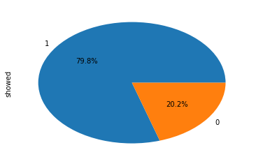

```python
df['showed'].value_counts().plot(kind='pie',autopct='%1.1f%%');
```

> It can be clearly seen that 20% of the patients did not attend their scheduled appointments.

### Research Question 2 ( What are the features that can be used to predict if the patients will attend thier appointments )

#### Here we are going to do some quick investigation regarding the patients who tend to miss their scheduled appointments

```python
df_miss_app = df[df['showed']==0]
df_catch_app = df[df['showed']==1]
#df_miss_app.describe()
```

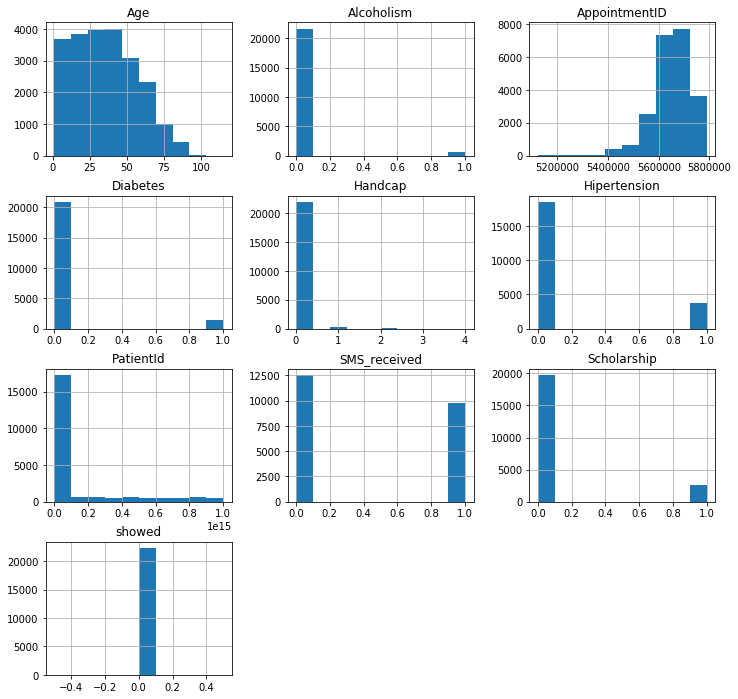

```python
df_miss_app.hist(figsize=(12,12));
```

```python
df_miss_app['Age'].describe()
```

```
count    22319.000000
mean        35.379533
std         21.163065
min          1.000000
25%         18.000000
50%         34.000000
75%         51.000000
max        115.000000
Name: Age, dtype: float64
```

```python
df_catch_app['Age'].describe()
```

```
count    88208.000000
mean        39.009875
std         22.276957
min          1.000000
25%         21.000000
50%         38.000000
75%         56.000000
max        115.000000
Name: Age, dtype: float64
```

```python
#df_miss_app['Gender'].describe()
```

# AGE

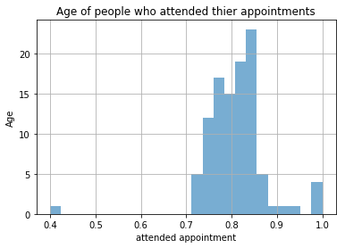

```python
pt.title("Age of people who attended thier appointments")
pt.xlabel("attended appointment")
pt.ylabel("Age")
df.groupby('Age')['showed'].mean().hist(alpha=0.6,bins=25,label='attended appointment');
```

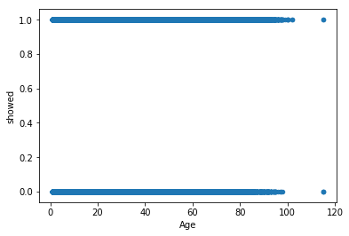

```python
df.plot(x='Age', y='showed', kind='scatter');
```

> We can see that younger people tend to miss their appointments

```python
# this function is used to plot graphs and to avoid code redundancy
def plot_function(fname):
  df.groupby(fname)['showed'].mean().plot(kind='bar');
  pt.xlabel("attended appointment")
  pt.ylabel(fname)
  pt.legend()
```

# GENDER

```python
print(df.groupby('Gender')['showed'].mean())
```

```
Gender
F    0.796854
M    0.800321
Name: showed, dtype: float64
```

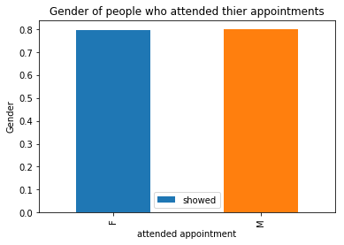

```python
pt.title("Gender of people who attended thier appointments")
plot_function('Gender')
```

```python
# get counts for each gender who showed
gender_counts = df.groupby(['Gender']).count()['showed']
gender_counts
```

```
Gender
F    71840
M    38687
Name: showed, dtype: int64
```

```python
# get counts of the number of patiencts who missed their appointments based on gender
att_counts = df_miss_app.groupby(['Gender']).count()['showed']
att_counts
```

```
Gender
F    14594
M     7725
Name: showed, dtype: int64
```

```python
# get proportions by dividing count of patients who missed thier appointments for each gender counts by total # of patience
att_proportions = att_counts / gender_counts
att_proportions
```

```
Gender
F    0.203146
M    0.199679
Name: showed, dtype: float64
```

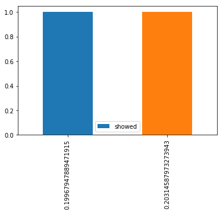

```python
#ind = df_miss_app['Gender'].value_counts().index
att_proportions.value_counts().plot(kind='bar')#, autopct='%1.1f%%');
pt.legend()
```

# SCHOLARSHIP

```python
print(df.groupby('Scholarship')['showed'].mean())
```

```
Scholarship
0    0.801928
1    0.762637
Name: showed, dtype: float64
```

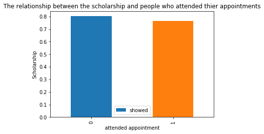

```python
pt.title("The relationship between the scholarship and people who attended thier appointments")
plot_function('Scholarship')
```

```python
# get counts for patient who have scholarship and who do not
sch_counts = df.groupby(['Scholarship']).count()['showed']
sch_counts
```

```
Scholarship
0    99666
1    10861
Name: showed, dtype: int64
```

```python
# get counts of the number of patiencts who have scholarship and who do not and both missed thier appintment
sch_miss_counts = df_miss_app.groupby(['Scholarship']).count()['showed']
sch_miss_counts
```

```
Scholarship
0    19741
1     2578
Name: showed, dtype: int64
```

```python
# get proportions by dividing count of patients who missed thier appointments  by total # of patients
sch_proportions = sch_miss_counts/sch_counts
sch_proportions
```

```
Scholarship
0    0.198072
1    0.237363
Name: showed, dtype: float64
```

> We can see that patients with scholarships tend to miss thier scheduled appointments compared to patients who do not have scholarships

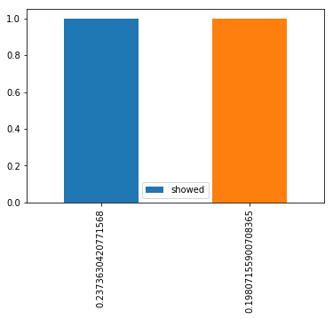

```python
#ind = df_miss_app['Gender'].value_counts().index
sch_proportions.value_counts().plot(kind='bar')#, autopct='%1.1f%%');
pt.legend()
```

> We can see that patients with scholarships tend to miss thier scheduled appointments compared to patients who do not have scholarships

# ALCOHOLISM

```python
print(df.groupby('Alcoholism')['showed'].mean())
```

```
Alcoholism
0    0.798054
1    0.798512
Name: showed, dtype: float64
```

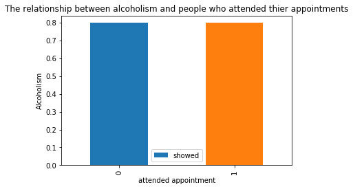

```python
pt.title("The relationship between alcoholism and people who attended thier appointments")
plot_function('Alcoholism')
```

```python
Alc_counts = df.groupby(['Alcoholism']).count()['showed']
Alc_counts
```

```
Alcoholism
0    107167
1      3360
Name: showed, dtype: int64
```

```python
Alc_miss_counts = df_miss_app.groupby(['Alcoholism']).count()['showed']
Alc_miss_counts
```

```
Alcoholism
0    21642
1      677
Name: showed, dtype: int64
```

```python
Alc_proportions = Alc_miss_counts/Alc_counts
Alc_proportions
```

```
Alcoholism
0    0.201946
1    0.201488
Name: showed, dtype: float64
```

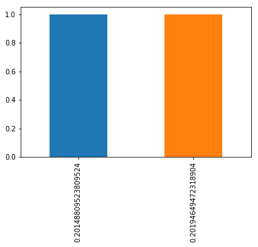

```python
#ind = df_miss_app['Gender'].value_counts().index
Alc_proportions.value_counts().plot(kind='bar')#, autopct='%1.1f%%');
```

> it seems that alcoholism does not affect the appointments attendance

# HYPERTENSION

```python
print(df.groupby('Hipertension')['showed'].mean())
```

```
Hipertension
0    0.790963
1    0.826980
Name: showed, dtype: float64
```

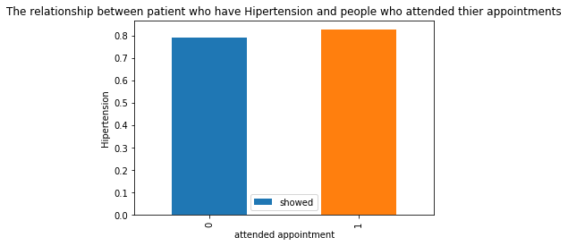

```python
pt.title("The relationship between patient who have Hipertension and people who attended thier appointments")
plot_function('Hipertension')
```

```python
Hip_counts = df.groupby(['Hipertension']).count()['showed']
Hip_counts
```

```
Hipertension
0    88726
1    21801
Name: showed, dtype: int64
```

```python
Hip_miss_counts = df_miss_app.groupby(['Hipertension']).count()['showed']
Hip_miss_counts
```

```
Hipertension
0    18547
1     3772
Name: showed, dtype: int64
```

```python
Hip_proportions = Hip_miss_counts/Hip_counts
Hip_proportions
```

```
Hipertension
0    0.209037
1    0.173020
Name: showed, dtype: float64
```

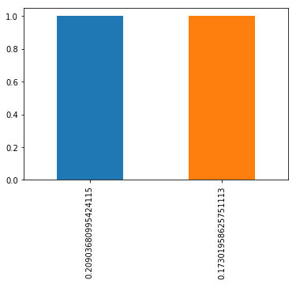

```python
#ind = df_miss_app['Gender'].value_counts().index
Hip_proportions.value_counts().plot(kind='bar')#, autopct='%1.1f%%');
```

> It seems that patients with hypertension tend to attend thier appointments

# Diabetes

```python
print(df.groupby('Diabetes')['showed'].mean())
```

```
Diabetes
0    0.796372
1    0.819967
Name: showed, dtype: float64
```

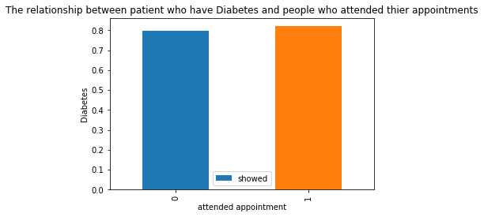

```python
pt.title("The relationship between patient who have Diabetes and people who attended thier appointments")
plot_function('Diabetes')
```

```python
Dia_counts = df.groupby(['Diabetes']).count()['showed']
Dia_counts
```

```
Diabetes
0    102584
1      7943
Name: showed, dtype: int64
```

```python
Dia_miss_counts = df_miss_app.groupby(['Diabetes']).count()['showed']
Dia_miss_counts
```

```
Diabetes
0    20889
1     1430
Name: showed, dtype: int64
```

```python
Dia_proportions = Dia_miss_counts/Dia_counts
Dia_proportions
```

```
Diabetes
0    0.203628
1    0.180033
Name: showed, dtype: float64
```

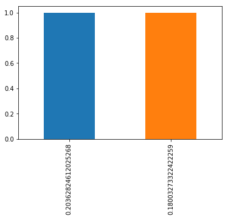

```python
Dia_proportions.value_counts().plot(kind='bar')#, autopct='%1.1f%%');
```

> It seems that patients with Diabetes tend to attend thier appointments

# HANDICAPPED

```python
print(df.groupby('Handcap')['showed'].mean())
```

```
Handcap
0    0.797647
1    0.820764
2    0.797814
3    0.769231
4    0.666667
Name: showed, dtype: float64
```

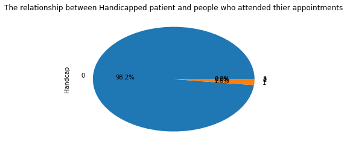

```python
pt.title("The relationship between Handicapped patient and people who attended thier appointments")
#plot_function('Handcap')

#df_miss_app['Handcap'].hist()
df_miss_app['Handcap'].value_counts().plot(kind='pie', autopct='%1.1f%%');
```

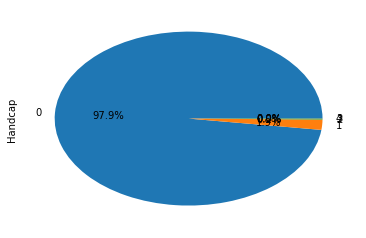

```python
df_catch_app['Handcap'].value_counts().plot(kind='pie', autopct='%1.1f%%');
```

```python
hnd_counts = df.groupby(['Handcap']).count()['showed']
hnd_counts
```

```
Handcap
0    108286
1      2042
2       183
3        13
4         3
Name: showed, dtype: int64
```

```python
hnd_miss_counts = df_miss_app.groupby(['Handcap']).count()['showed']
hnd_miss_counts
```

```
Handcap
0    21912
1      366
2       37
3        3
4        1
Name: showed, dtype: int64
```

```python
hnd_proportions = hnd_miss_counts/hnd_counts
hnd_proportions
```

```
Handcap
0    0.202353
1    0.179236
2    0.202186
3    0.230769
4    0.333333
Name: showed, dtype: float64
```

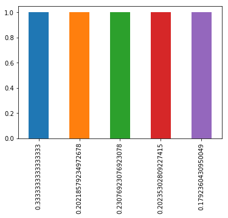

```python
#ind = df_miss_app['Gender'].value_counts().index
hnd_proportions.value_counts().plot(kind='bar')#, autopct='%1.1f%%');
```

# SMS_RECEIVED

```python
print(df.groupby('SMS_received')['showed'].mean())
```

```
SMS_received
0    0.832967
1    0.724255
Name: showed, dtype: float64
```

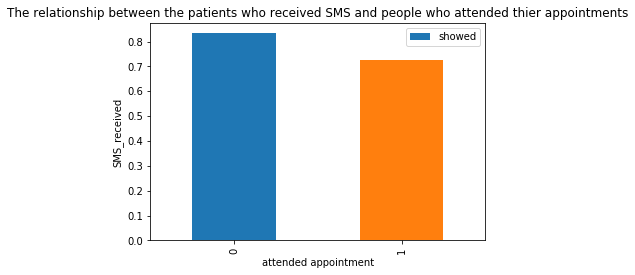

```python
pt.title("The relationship between the patients who received SMS and people who attended thier appointments")
plot_function('SMS_received')
```

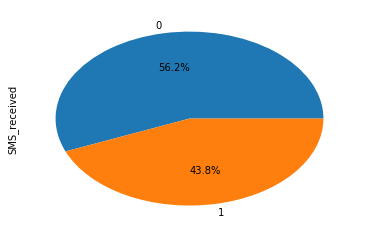

```python
df_miss_app['SMS_received'].value_counts().plot(kind='pie', autopct='%1.1f%%');
```

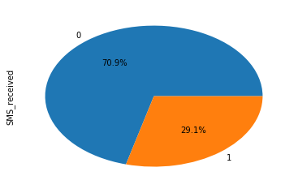

```python
df_catch_app['SMS_received'].value_counts().plot(kind='pie', autopct='%1.1f%%');
```

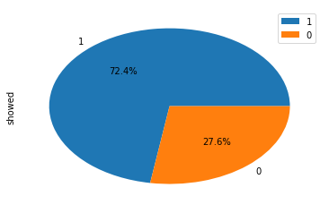

```python
df_SMS_received = df[df['SMS_received']==1]
df_SMS_received['showed'].value_counts().plot(kind='pie', autopct='%1.1f%%');
pt.legend();
```

```python
df_SMS_received.describe()
```

|  | PatientId | AppointmentID | Age | Scholarship | Hipertension | Diabetes | Alcoholism | Handcap | SMS_received | showed |
| --- | --- | --- | --- | --- | --- | --- | --- | --- | --- | --- |
| count | 3.548200e+04 | 3.548200e+04 | 35482.000000 | 35482.000000 | 35482.000000 | 35482.000000 | 35482.000000 | 35482.000000 | 35482.0 | 35482.000000 |
| mean | 1.438652e+14 | 5.648697e+06 | 38.451432 | 0.098782 | 0.193619 | 0.066400 | 0.023871 | 0.016572 | 1.0 | 0.724255 |
| std | 2.518491e+14 | 8.066133e+04 | 21.498636 | 0.298374 | 0.395140 | 0.248983 | 0.152650 | 0.139882 | 0.0 | 0.446895 |
| min | 5.376153e+05 | 5.030230e+06 | 1.000000 | 0.000000 | 0.000000 | 0.000000 | 0.000000 | 0.000000 | 1.0 | 0.000000 |
| 25% | 3.932647e+12 | 5.605518e+06 | 21.000000 | 0.000000 | 0.000000 | 0.000000 | 0.000000 | 0.000000 | 1.0 | 0.000000 |
| 50% | 2.982433e+13 | 5.648944e+06 | 37.088874 | 0.000000 | 0.000000 | 0.000000 | 0.000000 | 0.000000 | 1.0 | 1.000000 |
| 75% | 9.358590e+13 | 5.716710e+06 | 55.000000 | 0.000000 | 0.000000 | 0.000000 | 0.000000 | 0.000000 | 1.0 | 1.000000 |
| max | 9.999320e+14 | 5.773092e+06 | 115.000000 | 1.000000 | 1.000000 | 1.000000 | 1.000000 | 4.000000 | 1.0 | 1.000000 |

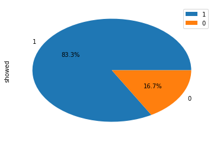

```python
df_SMS_Nreceived = df[df['SMS_received']==0]
df_SMS_Nreceived['showed'].value_counts().plot(kind='pie', autopct='%1.1f%%');
pt.legend();
```

```python
sms_counts = df.groupby(['SMS_received']).count()['showed']
sms_counts
```

```
SMS_received
0    75045
1    35482
Name: showed, dtype: int64
```

```python
sms_miss_counts = df_miss_app.groupby(['SMS_received']).count()['showed']
sms_miss_counts
```

```
SMS_received
0    12535
1     9784
Name: showed, dtype: int64
```

```python
sms_proportions = sms_miss_counts/sms_counts
sms_proportions
```

```
SMS_received
0    0.167033
1    0.275745
Name: showed, dtype: float64
```

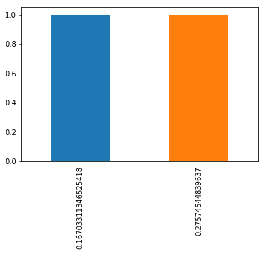

```python
#ind = df_miss_app['Gender'].value_counts().index
sms_proportions.value_counts().plot(kind='bar')#, autopct='%1.1f%%');
```

> It can be clear that sendeing a rminder message does not impove the attendancy of the patients

## Limitations

> Every study has certain limitations, and this one is not an exception. In fact, there are missing festures that could be beneficial for this study such as the distance between the patient home and the hospital. In addition, some data is not accurate such as patient age, some rows contain zero and negative values.

## Conclusion

> • It can be clearly seen that younger patients tend to miss their scheduled appointments.

> • We can see that patients with scholarships tend to miss thier scheduled appointments compared to patients who do not have scholarships

> • It seems that alcoholism does not affect the appointments attendance

> • It seems that patients with hypertension tend to attend thier appointments

> • It seems that patients with Diabetes tend to attend thier appointments

> • It can be clear that sendeing a rminder message does not impove the attendancy of the patients